# IODS course project

## 3. Variables to study

> Aim of the analysis is to study the relationship between high/low alcohol consumption and some other variables

My own asumption is that there might be correlation between alcohol consumption and:

- student **sex**, male generally use more alcohol
- I would guess that drinking during the week reduces **school achievements** and increases **failures** in a long run.
- I would assume that bad **family relatioship** indicate high **alcohol consumption** but would it be predictive? Or just cause.
- It would be also interesting to know if parents divorce(**Pstatus**) would increase alchol consumption I would guess that yes.

Next couple of plots will be drawn.

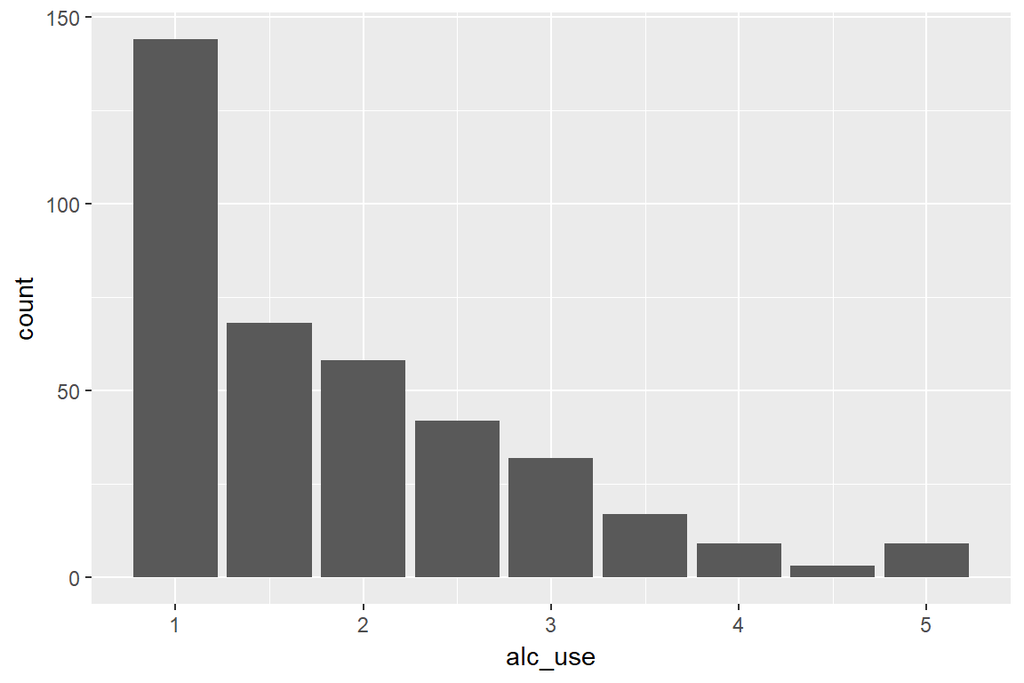

```r
library("ggplot2")
library("dplyr")
library("tidyr")

g1 <- ggplot(data=alc, aes(x=alc_use)) + geom_bar()
g1
```

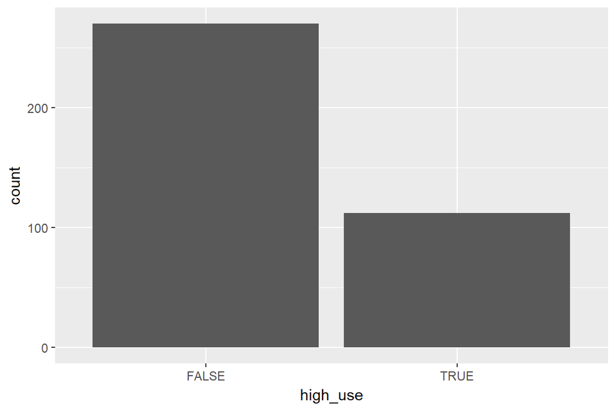

```r
g2 <- ggplot(data=alc, aes(x=high_use)) + geom_bar()
g2
```

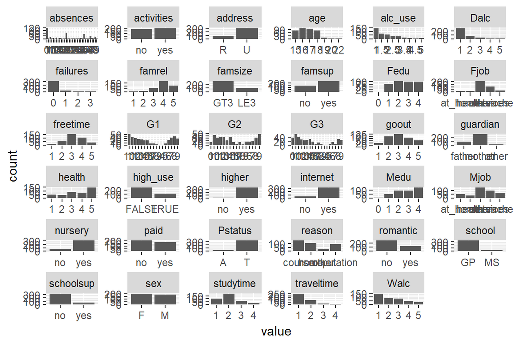

```r
# gather columns int key-value pairs and then plot each pair
gather(alc) %>% ggplot(aes(value)) + facet_wrap("key", scales = "free") + geom_bar()
```

## 4. Numerical and graphical exploration of the data

### Cohabitation status and course failures

```r
# Let's produce some summary statistics. First we group data based on sex and high_use. And then based on those grouppings summary statistics is generated
alc %>% group_by(sex,high_use) %>% summarise(count = n(), mean_grade=mean(G3))
```

```
## # A tibble: 4 x 4
## # Groups:   sex [?]
##      sex high_use count mean_grade
##   <fctr>    <lgl> <int>      <dbl>
## 1      F    FALSE   157   9.687898
## 2      F     TRUE    41  10.414634
## 3      M    FALSE   113  11.610619
## 4      M     TRUE    71   9.971831
```

```r
alc %>% group_by(Pstatus,high_use) %>% summarise(count = n(), mean_grade=mean(G3))
```

```
## # A tibble: 4 x 4
## # Groups:   Pstatus [?]
##   Pstatus high_use count mean_grade
##    <fctr>    <lgl> <int>      <dbl>
## 1       A    FALSE    26   11.26923
## 2       A     TRUE    12   10.91667
## 3       T    FALSE   244   10.40984
## 4       T     TRUE   100   10.04000
```

```r
alc %>% group_by(failures,high_use) %>% summarise(count = n(), mean_grade=mean(G3))
```

```
## # A tibble: 8 x 4
## # Groups:   failures [?]
##   failures high_use count mean_grade
##      <int>    <lgl> <int>      <dbl>
## 1        0    FALSE   234  11.358974
## 2        0     TRUE    82  10.902439
## 3        1    FALSE    22   5.545455
## 4        1     TRUE    16   9.187500
## 5        2    FALSE     5   3.400000
## 6        2     TRUE     6   6.000000
## 7        3    FALSE     9   4.000000
## 8        3     TRUE     8   7.250000
```

Suprisingly it seems that final grade for females is quite same even if female is **high alcohol user**. For men there is clear difference between two groups. Maybe men drink more if they are high users?

Our orginal assumption with relation of family status and high_use seem to be incorrect. Suprisingly it seems that students who come from divorced families succeed better in courses.

It seems that there might be some trend with high use and failure rate from courses.

### Age

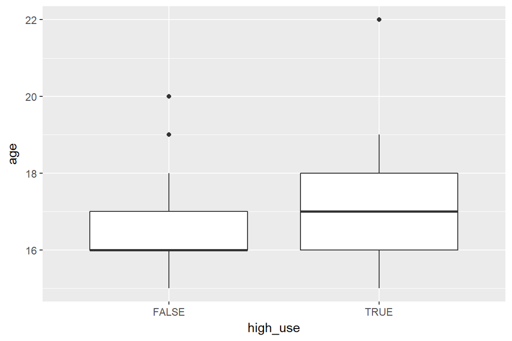

```r
# initialize a plot of high_use and age
g1 <- ggplot(alc, aes(x = high_use, y = age))

# define the plot as a boxplot and draw it
g1 + geom_boxplot() + ylab("age")
```

It seems that elder students drink more.

### Relationship status

Let still check if there is any affect if student is single or in “romantic relationship”.

```r
alc %>% group_by(romantic,high_use) %>% summarise(count = n(), mean_grade=mean(G3))
```

```
## # A tibble: 4 x 4
## # Groups:   romantic [?]
##   romantic high_use count mean_grade
##     <fctr>    <lgl> <int>      <dbl>
## 1       no    FALSE   182  11.043956
## 2       no     TRUE    79  10.367089
## 3      yes    FALSE    88   9.352273
## 4      yes     TRUE    33   9.575758
```

It seems that there might be something. Romantic relatioship might protect a bit from heavy use but might be bad for your grade.

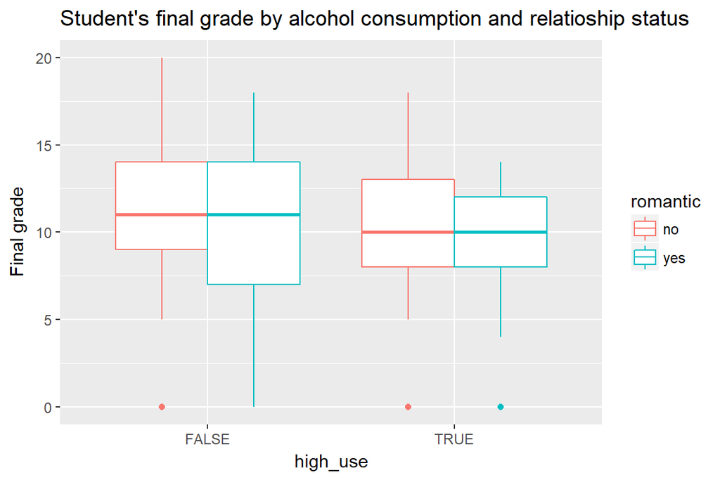

```r
g2 <- ggplot(alc, aes(x=high_use, y=G3, col=romantic))
# define the plot as a boxplot and draw it
g2 + geom_boxplot() + ggtitle("Student's final grade by alcohol consumption and relatioship status")+ ylab("Final grade")
```

## Internet

Another thing which came to my mind is that there might be correlation with internet availability and alcohol use.

```r
alc %>% group_by(internet,high_use) %>% summarise(count = n(), mean_grade=mean(G3))
```

```
## # A tibble: 4 x 4
## # Groups:   internet [?]
##   internet high_use count mean_grade
##     <fctr>    <lgl> <int>      <dbl>
## 1       no    FALSE    43   9.488372
## 2       no     TRUE    15   9.200000
## 3      yes    FALSE   227  10.682819
## 4      yes     TRUE    97  10.278351
```

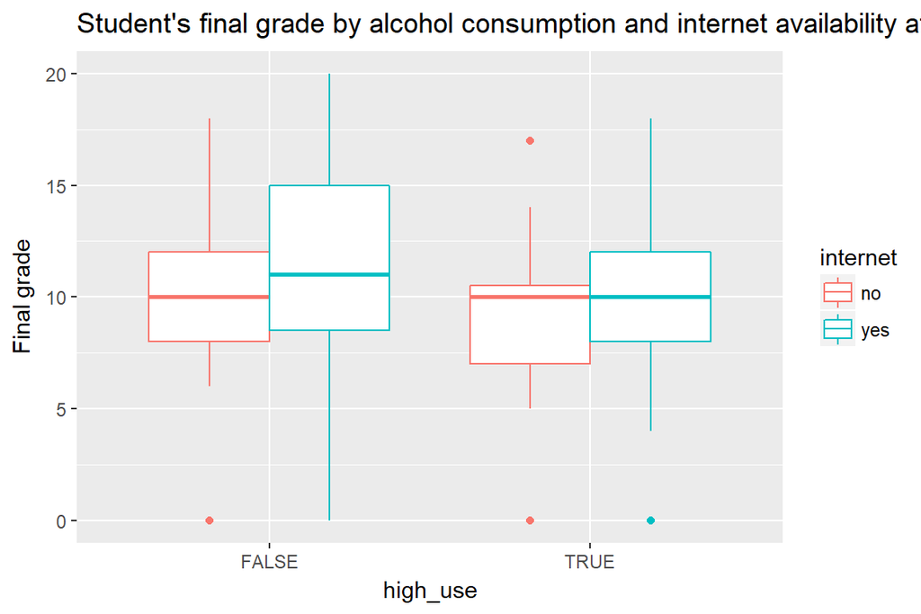

```r
g2 <- ggplot(alc, aes(x=high_use, y=G3, col=internet))
# define the plot as a boxplot and draw it
g2 + geom_boxplot() + ggtitle("Student's final grade by alcohol consumption and internet availability at home")+ ylab("Final grade")
```

## Family relaltion ship

Let’s see if there is some correlation with family relatiship and alcohol consumption

```r
alc %>% group_by(famrel,high_use) %>% summarise(count = n(), mean_grade=mean(G3))
```

```
## # A tibble: 10 x 4
## # Groups:   famrel [?]
##    famrel high_use count mean_grade
##     <int>    <lgl> <int>      <dbl>
##  1      1    FALSE     7   8.571429
##  2      1     TRUE     2  12.500000
##  3      2    FALSE     9   9.666667
##  4      2     TRUE     9  10.111111
##  5      3    FALSE    40  10.000000
##  6      3     TRUE    26  10.038462
##  7      4    FALSE   131  10.335878
##  8      4     TRUE    52  10.461538
##  9      5    FALSE    83  11.228916
## 10      5     TRUE    23   9.304348
```

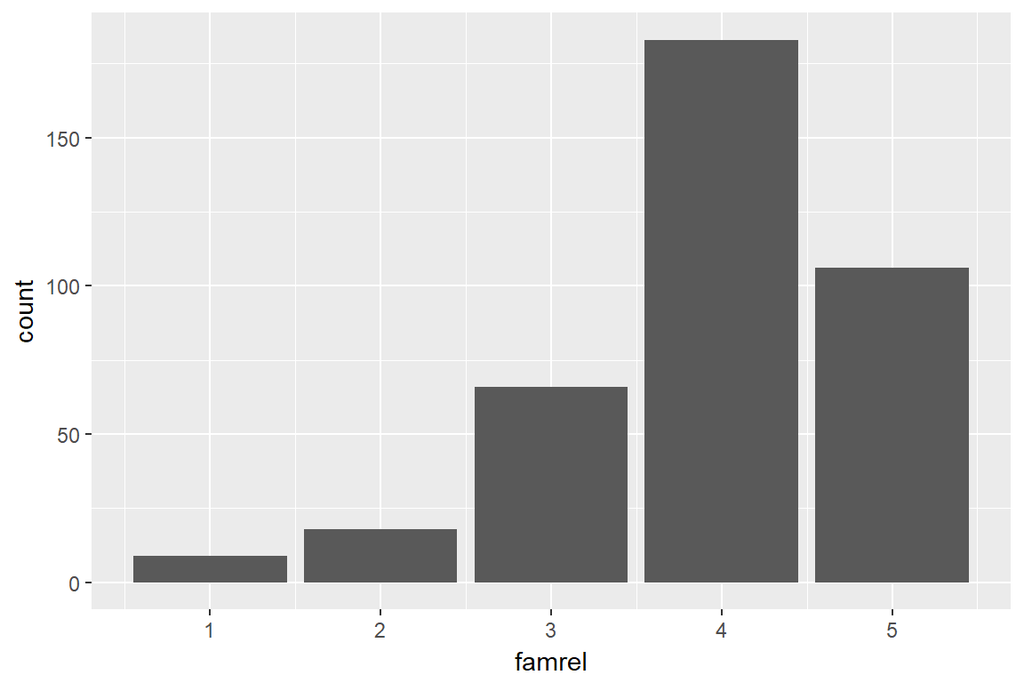

```r
alc %>%  ggplot( aes(x=famrel)) + geom_bar()
```

## Absence and sex

Let’s also draw plots drawn in a exercice.

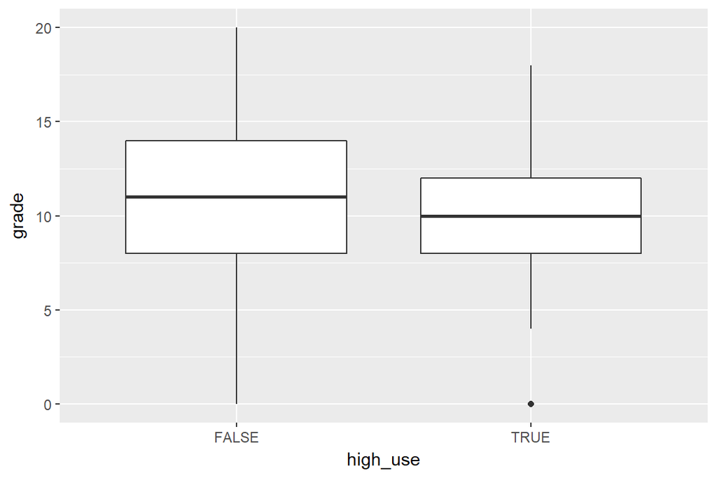

```r
# initialize a plot of high_use and G3
g1 <- ggplot(alc, aes(x = high_use, y = G3))

# define the plot as a boxplot and draw it
g1 + geom_boxplot() + ylab("grade")
```

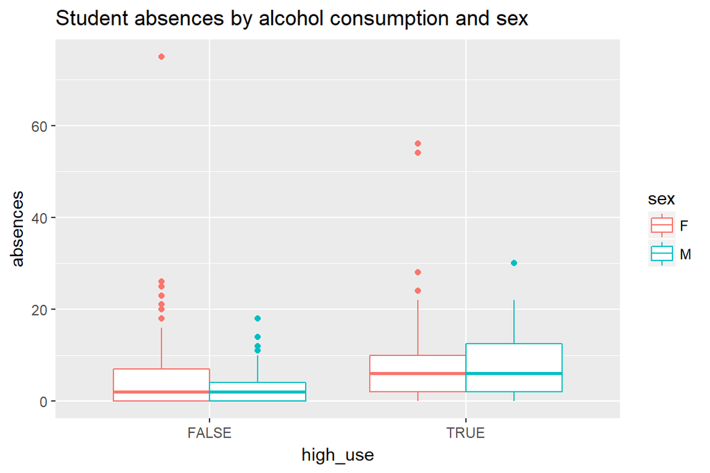

```r
# initialise a plot of high_use and absences

g2 <- ggplot(alc, aes(x=high_use, y=absences, col=sex))
# define the plot as a boxplot and draw it
g2 + geom_boxplot() + ggtitle("Student absences by alcohol consumption and sex")
```

It seems that there might be slighty more absence for those students who are heavy users.

## 5. Logistic regression model

Let see if statistical methods validates our visual inspection. Binary variable `hig_use`is used as a target variable and explanotary variables are first course failures, parents cohabitation staturs, relationship to family and sex.

```r
# find the model with glm()
m <- glm(high_use ~ failures + Pstatus+sex+famrel, data = alc, family = "binomial")

# print out a summary of the model

summary(m)
```

```
##
## Call:
## glm(formula = high_use ~ failures + Pstatus + sex + famrel, family = "binomial",
##     data = alc)
##
## Deviance Residuals:
##     Min       1Q   Median       3Q      Max
## -1.5306  -0.8276  -0.6224   1.2098   2.0052
##
## Coefficients:
##             Estimate Std. Error z value Pr(>|z|)
## (Intercept)  -0.1294     0.5918  -0.219  0.82695
## failures      0.3836     0.1479   2.595  0.00947 **
## PstatusT     -0.1188     0.3853  -0.308  0.75786
## sexM          0.9286     0.2387   3.890  0.00010 ***
## famrel       -0.3237     0.1241  -2.608  0.00911 **
## ---
## Signif. codes:  0 '***' 0.001 '**' 0.01 '*' 0.05 '.' 0.1 ' ' 1
##
## (Dispersion parameter for binomial family taken to be 1)
##
##     Null deviance: 462.21  on 381  degrees of freedom
## Residual deviance: 432.96  on 377  degrees of freedom
## AIC: 442.96
##
## Number of Fisher Scoring iterations: 4
```

```r
# print out the coefficients of the model
```

It seems that there is statistical significance between failures, sex and family relationships. Let’s keep them in a model.

```r
# find the model with glm()
m <- glm(high_use ~ failures +sex+famrel, data = alc, family = "binomial")

# print out a summary of the model

summary(m)
```

```
##
## Call:
## glm(formula = high_use ~ failures + sex + famrel, family = "binomial",
##     data = alc)
##
## Deviance Residuals:
##     Min       1Q   Median       3Q      Max
## -1.5370  -0.8160  -0.6261   1.2434   2.0004
##
## Coefficients:
##             Estimate Std. Error z value Pr(>|z|)
## (Intercept)  -0.2282     0.4977  -0.459 0.646569
## failures      0.3835     0.1478   2.595 0.009457 **
## sexM          0.9266     0.2386   3.884 0.000103 ***
## famrel       -0.3254     0.1240  -2.624 0.008686 **
## ---
## Signif. codes:  0 '***' 0.001 '**' 0.01 '*' 0.05 '.' 0.1 ' ' 1
##
## (Dispersion parameter for binomial family taken to be 1)
##
##     Null deviance: 462.21  on 381  degrees of freedom
## Residual deviance: 433.05  on 378  degrees of freedom
## AIC: 441.05
##
## Number of Fisher Scoring iterations: 4
```

```r
# print out the coefficients of the model
```

No we can look at the coefficients of the model and calculate odds ratio(which tell you how strongly presence of one attribute is associated with the presence of high alcohol use) and coeffidence intervals(which tell which area of the value is considered true)

```r
coef(m)
```

```
## (Intercept)    failures        sexM      famrel
##  -0.2281944   0.3834858   0.9266311  -0.3254416
```

```r
# compute odds ratios (OR)
OR <- coef(m) %>% exp

# compute confidence intervals (CI)
CI <- confint(m) %>% exp()
# print out the odds ratios with their confidence intervals
print(cbind(OR, CI))
```

```
##                    OR     2.5 %    97.5 %
## (Intercept) 0.7959695 0.2969483 2.1063106
## failures    1.4673907 1.0979358 1.9680962
## sexM        2.5259851 1.5908489 4.0600334
## famrel      0.7222083 0.5650089 0.9204315
```

## 6. Exploration of predictive power of the model

Let’s research predictive power of my model

```r
# Let's use model which was created in a last step
m <- glm(high_use ~ failures +sex+famrel, data = alc, family = "binomial")
# predict() the probability of high_use
probabilities <- predict(m, type = "response")

# add the predicted probabilities to 'alc'
alc <- mutate(alc, probability = probabilities)

# use the probabilities to make a prediction of high_use
alc <- mutate(alc, prediction = probabilities>0.5)
# see the last ten original classes, predicted probabilities, and class predictions
select(alc, failures, absences, sex, high_use, probability, prediction) %>% tail(10)
```

```
##     failures absences sex high_use probability prediction
## 373        1        0   M    FALSE   0.4452593      FALSE
## 374        1       14   M     TRUE   0.3669589      FALSE
## 375        0        2   F    FALSE   0.1352398      FALSE
## 376        0        7   F    FALSE   0.1779994      FALSE
## 377        1        0   F    FALSE   0.1866515      FALSE
## 378        0        0   F    FALSE   0.1779994      FALSE
## 379        1        0   F    FALSE   0.4575648      FALSE
## 380        1        0   F    FALSE   0.4575648      FALSE
## 381        0        3   M     TRUE   0.5118861       TRUE
## 382        0        0   M     TRUE   0.3535823      FALSE
```

```r
# tabulate the target variable versus the predictions
table(high_use = alc$high_use, prediction = alc$prediction)
```

```
##         prediction
## high_use FALSE TRUE
##    FALSE   258   12
##    TRUE     96   16
```

It seems that model quite good detects when some is not heavy user of alcohol. But quite often doesn’t detect heavy user’s of alcohol.

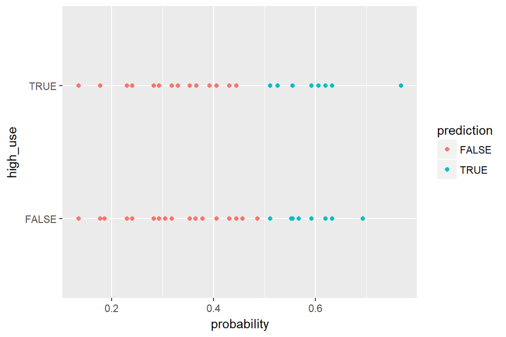

```r
# initialize a plot of 'high_use' versus 'probability' in 'alc'
g <- ggplot(alc, aes(x = probability, y = high_use, col=prediction))

# define the geom as points and draw the plot
g + geom_point()
```

```r
# tabulate the target variable versus the predictions
table(high_use = alc$high_use, prediction = alc$prediction) %>% prop.table() %>% addmargins()
```

```
##         prediction
## high_use      FALSE       TRUE        Sum
##    FALSE 0.67539267 0.03141361 0.70680628
##    TRUE  0.25130890 0.04188482 0.29319372
##    Sum   0.92670157 0.07329843 1.00000000
```

Tabulate plot confirms this. So quite often when some one is heavy user our model doesn’t detect that.

Let’s calculate average number of incorrectly classified observations

```r
# the logistic regression model m and dataset alc with predictions are available

# define a loss function (mean prediction error)
loss_func <- function(class, prob) {
  n_wrong <- abs(class - prob) > 0.5
  mean(n_wrong)
}

# call loss_func to compute the average number of wrong predictions in the (training) data
loss_func(class = alc$high_use, prob = alc$probability)
```

```
## [1] 0.2827225
```

Finally let’s try crossvalidation

```r
# the logistic regression model m and dataset alc (with predictions) are available

# define a loss function (average prediction error)
loss_func <- function(class, prob) {
  n_wrong <- abs(class - prob) > 0.5
  mean(n_wrong)
}

# compute the average number of wrong predictions in the (training) data
loss_func(alc$high_use, alc$probability)
```

```
## [1] 0.2827225
```

```r
# K-fold cross-validation
library(boot)
cv <- cv.glm(data = alc, cost = loss_func, glmfit = m, K = 10)

# average number of wrong predictions in the cross validation
cv$delta[1]
```

```
## [1] 0.2931937
```

## 7. Bonus

Let’s try to find better model:

```r
# Let's try to make better model
m2 <- glm(high_use ~ failures +sex+famrel+internet+romantic+school+age+address+Fedu+Mjob+reason+guardian+traveltime+studytime+schoolsup+famsup+paid+activities+nursery+higher+freetime+goout+health+absences, data = alc, family = "binomial")

summary(m2)
```

```
##
## Call:
## glm(formula = high_use ~ failures + sex + famrel + internet +
##     romantic + school + age + address + Fedu + Mjob + reason +
##     guardian + traveltime + studytime + schoolsup + famsup +
##     paid + activities + nursery + higher + freetime + goout +
##     health + absences, family = "binomial", data = alc)
##
## Deviance Residuals:
##     Min       1Q   Median       3Q      Max
## -2.1975  -0.6599  -0.3811   0.5451   2.8189
##
## Coefficients:
##                  Estimate Std. Error z value Pr(>|z|)
## (Intercept)      -2.14415    2.83976  -0.755 0.450222
## failures          0.08481    0.20265   0.418 0.675596
## sexM              0.91204    0.32653   2.793 0.005221 **
## famrel           -0.56044    0.16295  -3.439 0.000583 ***
## internetyes       0.17831    0.44121   0.404 0.686108
## romanticyes      -0.50614    0.32059  -1.579 0.114384
## schoolMS         -0.49164    0.55307  -0.889 0.374046
## age               0.03112    0.14490   0.215 0.829941
## addressU         -0.78840    0.40776  -1.933 0.053178 .
## Fedu              0.02649    0.15321   0.173 0.862712
## Mjobhealth       -0.84648    0.66722  -1.269 0.204556
## Mjobother        -0.81116    0.46293  -1.752 0.079732 .
## Mjobservices     -0.59489    0.50675  -1.174 0.240427
## Mjobteacher      -0.40144    0.56483  -0.711 0.477253
## reasonhome        0.34792    0.37868   0.919 0.358215
## reasonother       1.24089    0.51734   2.399 0.016458 *
## reasonreputation -0.02286    0.39953  -0.057 0.954379
## guardianmother   -0.73870    0.35236  -2.096 0.036046 *
## guardianother     0.17231    0.75576   0.228 0.819646
## traveltime        0.31205    0.22523   1.385 0.165903
## studytime        -0.30201    0.19874  -1.520 0.128597
## schoolsupyes     -0.07704    0.45303  -0.170 0.864970
## famsupyes        -0.24440    0.31822  -0.768 0.442486
## paidyes           0.62111    0.31221   1.989 0.046658 *
## activitiesyes    -0.63338    0.30740  -2.060 0.039355 *
## nurseryyes       -0.40149    0.35691  -1.125 0.260632
## higheryes        -0.17789    0.71294  -0.250 0.802959
## freetime          0.21734    0.16115   1.349 0.177440
## goout             0.87860    0.15003   5.856 4.73e-09 ***
## health            0.17720    0.11000   1.611 0.107190
## absences          0.07495    0.01981   3.783 0.000155 ***
## ---
## Signif. codes:  0 '***' 0.001 '**' 0.01 '*' 0.05 '.' 0.1 ' ' 1
##
## (Dispersion parameter for binomial family taken to be 1)
##
##     Null deviance: 462.21  on 381  degrees of freedom
## Residual deviance: 325.52  on 351  degrees of freedom
## AIC: 387.52
##
## Number of Fisher Scoring iterations: 5
```

```r
# predict() the probability of high_use
probabilities <- predict(m2, type = "response")

# add the predicted probabilities to 'alc'
alc <- mutate(alc, probability = probabilities)

# use the probabilities to make a prediction of high_use
alc <- mutate(alc, prediction = probabilities>0.5)

# see the last ten original classes, predicted probabilities, and class predictions
select(alc, failures, absences, sex, high_use, probability, prediction) %>% tail(10)
```

```
##     failures absences sex high_use probability prediction
## 373        1        0   M    FALSE  0.36959402      FALSE
## 374        1       14   M     TRUE  0.76108921       TRUE
## 375        0        2   F    FALSE  0.39739473      FALSE
## 376        0        7   F    FALSE  0.27124438      FALSE
## 377        1        0   F    FALSE  0.02342151      FALSE
## 378        0        0   F    FALSE  0.10045836      FALSE
## 379        1        0   F    FALSE  0.01672880      FALSE
## 380        1        0   F    FALSE  0.01672880      FALSE
## 381        0        3   M     TRUE  0.85233886       TRUE
## 382        0        0   M     TRUE  0.19506553      FALSE
```

```r
# tabulate the target variable versus the predictions
table(high_use = alc$high_use, prediction = alc$prediction)
```

```
##         prediction
## high_use FALSE TRUE
##    FALSE   249   21
##    TRUE     52   60
```

```r
# the logistic regression model m and dataset alc (with predictions) are available

# define a loss function (average prediction error)
loss_func <- function(class, prob) {
  n_wrong <- abs(class - prob) > 0.5
  mean(n_wrong)
}

# compute the average number of wrong predictions in the (training) data
loss_func(alc$high_use, alc$probability)
```

```
## [1] 0.1910995
```

```r
# K-fold cross-validation
library(boot)
cv <- cv.glm(data = alc, cost = loss_func, glmfit = m2, K = 10)

# average number of wrong predictions in the cross validation
cv$delta[1]
```

```
## [1] 0.2329843
```

It seems that takin more variables in account error can be reduced.

# IV Clustering and classification

*Mikael Jumppanen 15.11.17*

## 1. Creation of the rmd file

## 2. Reading of the data

```r
library(MASS)
# loading of the data
data("Boston")

# exploration of the data
str(Boston)
```

```
## 'data.frame':    506 obs. of  14 variables:
##  $ crim   : num  0.00632 0.02731 0.02729 0.03237 0.06905 ...
##  $ zn     : num  18 0 0 0 0 0 12.5 12.5 12.5 12.5 ...
##  $ indus  : num  2.31 7.07 7.07 2.18 2.18 2.18 7.87 7.87 7.87 7.87 ...
##  $ chas   : int  0 0 0 0 0 0 0 0 0 0 ...
##  $ nox    : num  0.538 0.469 0.469 0.458 0.458 0.458 0.524 0.524 0.524 0.524 ...
##  $ rm     : num  6.58 6.42 7.18 7 7.15 ...
##  $ age    : num  65.2 78.9 61.1 45.8 54.2 58.7 66.6 96.1 100 85.9 ...
##  $ dis    : num  4.09 4.97 4.97 6.06 6.06 ...
##  $ rad    : int  1 2 2 3 3 3 5 5 5 5 ...
##  $ tax    : num  296 242 242 222 222 222 311 311 311 311 ...
##  $ ptratio: num  15.3 17.8 17.8 18.7 18.7 18.7 15.2 15.2 15.2 15.2 ...
##  $ black  : num  397 397 393 395 397 ...
##  $ lstat  : num  4.98 9.14 4.03 2.94 5.33 ...
##  $ medv   : num  24 21.6 34.7 33.4 36.2 28.7 22.9 27.1 16.5 18.9 ...
```

```r
dim(Boston)
```

```
## [1] 506  14
```

```r
summary(Boston)
```

```
##       crim                zn             indus            chas
##  Min.   : 0.00632   Min.   :  0.00   Min.   : 0.46   Min.   :0.00000
##  1st Qu.: 0.08204   1st Qu.:  0.00   1st Qu.: 5.19   1st Qu.:0.00000
##  Median : 0.25651   Median :  0.00   Median : 9.69   Median :0.00000
##  Mean   : 3.61352   Mean   : 11.36   Mean   :11.14   Mean   :0.06917
##  3rd Qu.: 3.67708   3rd Qu.: 12.50   3rd Qu.:18.10   3rd Qu.:0.00000
##  Max.   :88.97620   Max.   :100.00   Max.   :27.74   Max.   :1.00000
##       nox               rm             age              dis
##  Min.   :0.3850   Min.   :3.561   Min.   :  2.90   Min.   : 1.130
##  1st Qu.:0.4490   1st Qu.:5.886   1st Qu.: 45.02   1st Qu.: 2.100
##  Median :0.5380   Median :6.208   Median : 77.50   Median : 3.207
##  Mean   :0.5547   Mean   :6.285   Mean   : 68.57   Mean   : 3.795
##  3rd Qu.:0.6240   3rd Qu.:6.623   3rd Qu.: 94.08   3rd Qu.: 5.188
##  Max.   :0.8710   Max.   :8.780   Max.   :100.00   Max.   :12.127
##       rad              tax           ptratio          black
##  Min.   : 1.000   Min.   :187.0   Min.   :12.60   Min.   :  0.32
##  1st Qu.: 4.000   1st Qu.:279.0   1st Qu.:17.40   1st Qu.:375.38
##  Median : 5.000   Median :330.0   Median :19.05   Median :391.44
##  Mean   : 9.549   Mean   :408.2   Mean   :18.46   Mean   :356.67
##  3rd Qu.:24.000   3rd Qu.:666.0   3rd Qu.:20.20   3rd Qu.:396.23
##  Max.   :24.000   Max.   :711.0   Max.   :22.00   Max.   :396.90
##      lstat            medv
##  Min.   : 1.73   Min.   : 5.00
##  1st Qu.: 6.95   1st Qu.:17.02
##  Median :11.36   Median :21.20
##  Mean   :12.65   Mean   :22.53
##  3rd Qu.:16.95   3rd Qu.:25.00
##  Max.   :37.97   Max.   :50.00
```

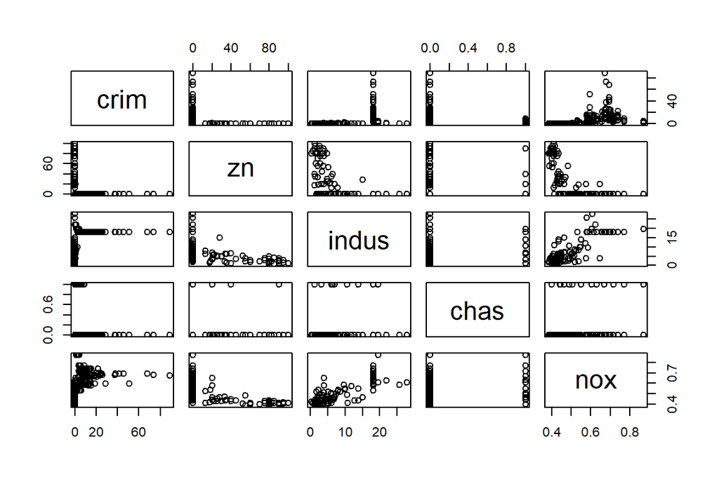

```r
plot(Boston[1:5])
```

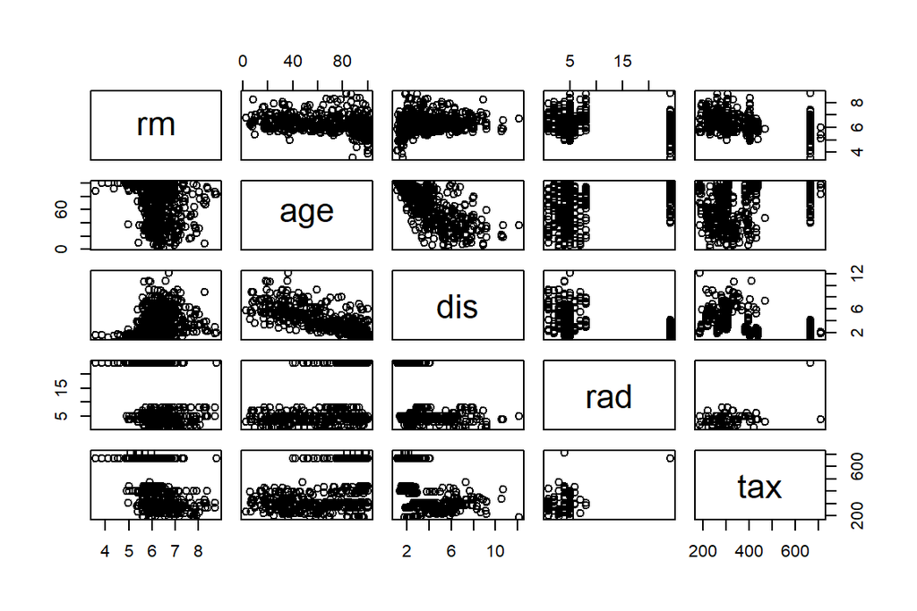

```r
plot(Boston[6:10])
```

Boston dataset has 14 varibles and 506 observations. Dataset tells about different areas of boston and includes following variables:

- **crim**: per capita crime rate by town.
- **zn**: proportion of residential land zoned for lots over 25,000 sq.ft.
- **indus**: proportion of non-retail business acres per town.
- **chas**: Charles River dummy variable (= 1 if tract bounds river; 0 otherwise).
- **nox**:nitrogen oxides concentration (parts per 10 million).
- **rm**: average number of rooms per dwelling.
- **age**: proportion of owner-occupied units built prior to 1940.
- **dis**: weighted mean of distances to five Boston employment centres.
- **rad**: index of accessibility to radial highways.
- **tax**: full-value property-tax rate per $10,000.
- **ptratio**: pupil-teacher ratio by town.
- **black**: 1000(Bk - 0.63)^2 where Bk is the proportion of blacks by town.
- **lstat**:lower status of the population (percent).
- **medv**: median value of owner-occupied homes in $1000s.